# Statistical Analysis of Online Shopping Behavior and Purchase Conversion

MAS291 Computer Project

Lương Triều Vỹ – QE200035 Phạm Bửu Thịnh – QE200023 Nguyễn Đức Duy – QE200054 Nguyễn Quốc Vương – QE200066 Đinh Đỗ Gia Huy – QE200022

24 Tháng Bảy 2026

# 1 Introduction

This project analyzes online shopping sessions from the UCI Online Shoppers Purchasing Intention Dataset. The population of interest is online shopping activity on an e-commerce platform. The observed dataset contains 12,330 independent sessions. Revenue divides the data into 1,908 purchase sessions and 10,422 non-purchase sessions.

The analysis studies engagement duration, conversion, differences between purchase outcomes, and the relationship between product-page count and total product-page duration.

## 1.1 Full dataset evidence - 12,330 sessions

The table below contains the complete dataset used in the project. `Session_ID` is the sequential identifier created for each online shopping session. The final three binary columns (`Revenue_int`, `Weekend_int`, and `Returning_int`) were derived for statistical calculations. Use the search box, column filters and page controls to inspect all 12,330 observations without expanding the report vertically.

| Session_ID | Administrative | Administrative_Duration | Informational | Informational_Duration | ProductRelated | ProductRelated_Duration | BounceRates | ExitRates | PageValues | SpecialDay | Month | OperatingSystems | Browser | Region | TrafficType | VisitorType | Weekend | Revenue | Revenue_int | Weekend_int | Returning_int |
| --- | --- | --- | --- | --- | --- | --- | --- | --- | --- | --- | --- | --- | --- | --- | --- | --- | --- | --- | --- | --- | --- |
| 1 | 0 | 0 | 0 | 0 | 1 | 0 | 0.2 | 0.2 | 0 | 0 | Feb | 1 | 1 | 1 | 1 | Returning_Visitor | False | False | 0 | 0 | 1 |
| 2 | 0 | 0 | 0 | 0 | 2 | 64 | 0 | 0.1 | 0 | 0 | Feb | 2 | 2 | 1 | 2 | Returning_Visitor | False | False | 0 | 0 | 1 |
| 3 | 0 | 0 | 0 | 0 | 1 | 0 | 0.2 | 0.2 | 0 | 0 | Feb | 4 | 1 | 9 | 3 | Returning_Visitor | False | False | 0 | 0 | 1 |
| 4 | 0 | 0 | 0 | 0 | 2 | 2.666666667 | 0.05 | 0.14 | 0 | 0 | Feb | 3 | 2 | 2 | 4 | Returning_Visitor | False | False | 0 | 0 | 1 |
| 5 | 0 | 0 | 0 | 0 | 10 | 627.5 | 0.02 | 0.05 | 0 | 0 | Feb | 3 | 3 | 1 | 4 | Returning_Visitor | True | False | 0 | 1 | 1 |
| 6 | 0 | 0 | 0 | 0 | 19 | 154.2166667 | 0.015789474 | 0.024561404 | 0 | 0 | Feb | 2 | 2 | 1 | 3 | Returning_Visitor | False | False | 0 | 0 | 1 |
| 7 | 0 | 0 | 0 | 0 | 1 | 0 | 0.2 | 0.2 | 0 | 0.4 | Feb | 2 | 4 | 3 | 3 | Returning_Visitor | False | False | 0 | 0 | 1 |
| 8 | 1 | 0 | 0 | 0 | 0 | 0 | 0.2 | 0.2 | 0 | 0 | Feb | 1 | 2 | 1 | 5 | Returning_Visitor | True | False | 0 | 1 | 1 |
| 9 | 0 | 0 | 0 | 0 | 2 | 37 | 0 | 0.1 | 0 | 0.8 | Feb | 2 | 2 | 2 | 3 | Returning_Visitor | False | False | 0 | 0 | 1 |
| 10 | 0 | 0 | 0 | 0 | 3 | 738 | 0 | 0.022222222 | 0 | 0.4 | Feb | 2 | 4 | 1 | 2 | Returning_Visitor | False | False | 0 | 0 | 1 |

[output cut: 12320 more lines]

# 2 Task 1 - Exploratory Data Analysis

## 2.1 Structure and data quality

| Measure | Result | Interpretation |
| --- | --- | --- |
| Rows | 12330 | One row per online session |
| Original variables | 18 | Original UCI variables, including Revenue |
| Missing cells | 0 | No missing values expected |
| Duplicate rows | 125 | Exact duplicate feature vectors; retained for analysis |
| Purchase sessions | 1908 | Revenue = TRUE |
| Non-purchase sessions | 10422 | Revenue = FALSE |
| Minimum group size | 1908 | Exceeds required 500 observations |

There are no missing values. Exact duplicate feature vectors are reported but retained because sessions with identical behavior may still represent genuine observations. Both groups exceed the required minimum of 500 observations.

## 2.2 Descriptive statistics

| Group | Variable | n | Mean | Median | SD | Min | Q1 | Q3 | Max | Skewness | IQR_outliers |
| --- | --- | --- | --- | --- | --- | --- | --- | --- | --- | --- | --- |
| Purchase | Administrative | 1908 | 3.394 | 2.000 | 3.731 | 0 | 0.000 | 5.000 | 26.000 | 1.455 | 58 |
| Purchase | Administrative_Duration | 1908 | 119.483 | 52.367 | 201.115 | 0 | 0.000 | 151.083 | 2086.750 | 3.985 | 143 |
| Purchase | Informational | 1908 | 0.786 | 0.000 | 1.521 | 0 | 0.000 | 1.000 | 12.000 | 2.699 | 223 |
| Purchase | Informational_Duration | 1908 | 57.611 | 0.000 | 171.619 | 0 | 0.000 | 19.000 | 1767.667 | 4.983 | 367 |
| Purchase | ProductRelated | 1908 | 48.210 | 29.000 | 58.267 | 0 | 15.000 | 57.000 | 534.000 | 3.259 | 166 |
| Purchase | ProductRelated_Duration | 1908 | 1876.210 | 1109.906 | 2312.214 | 0 | 541.906 | 2266.011 | 27009.859 | 3.338 | 166 |
| Purchase | BounceRates | 1908 | 0.005 | 0.000 | 0.012 | 0 | 0.000 | 0.006 | 0.200 | 8.277 | 156 |
| Purchase | ExitRates | 1908 | 0.020 | 0.016 | 0.016 | 0 | 0.010 | 0.025 | 0.200 | 3.478 | 95 |
| Purchase | PageValues | 1908 | 27.265 | 16.758 | 35.192 | 0 | 3.641 | 38.898 | 361.764 | 3.252 | 89 |
| Purchase | SpecialDay | 1908 | 0.023 | 0.000 | 0.124 | 0 | 0.000 | 0.000 | 1.000 | 5.792 | 77 |
| No purchase | Administrative | 10422 | 2.118 | 0.000 | 3.202 | 0 | 0.000 | 3.000 | 27.000 | 2.095 | 793 |
| No purchase | Administrative_Duration | 10422 | 73.740 | 0.000 | 171.018 | 0 | 0.000 | 83.000 | 3398.750 | 6.104 | 1042 |
| No purchase | Informational | 10422 | 0.452 | 0.000 | 1.212 | 0 | 0.000 | 0.000 | 24.000 | 4.450 | 2018 |
| No purchase | Informational_Duration | 10422 | 30.236 | 0.000 | 133.909 | 0 | 0.000 | 0.000 | 2549.375 | 8.433 | 1840 |
| No purchase | ProductRelated | 10422 | 28.715 | 16.000 | 40.745 | 0 | 6.000 | 35.000 | 705.000 | 4.694 | 813 |
| No purchase | ProductRelated_Duration | 10422 | 1069.988 | 510.190 | 1803.798 | 0 | 151.000 | 1331.817 | 63973.522 | 8.833 | 787 |
| No purchase | BounceRates | 10422 | 0.025 | 0.004 | 0.052 | 0 | 0.000 | 0.020 | 0.200 | 2.664 | 1299 |
| No purchase | ExitRates | 10422 | 0.047 | 0.029 | 0.051 | 0 | 0.016 | 0.054 | 0.200 | 1.940 | 1048 |
| No purchase | PageValues | 10422 | 1.976 | 0.000 | 9.072 | 0 | 0.000 | 0.000 | 246.759 | 9.559 | 1192 |
| No purchase | SpecialDay | 10422 | 0.068 | 0.000 | 0.209 | 0 | 0.000 | 0.000 | 1.000 | 3.083 | 1174 |

Purchase sessions view more product pages and spend more time on product-related pages on average. Non-purchase sessions have higher bounce and exit rates. Means exceed medians for several behavioral variables, while positive skewness and high-end IQR outliers show strong right-skewness.

## 2.3 Visualizations

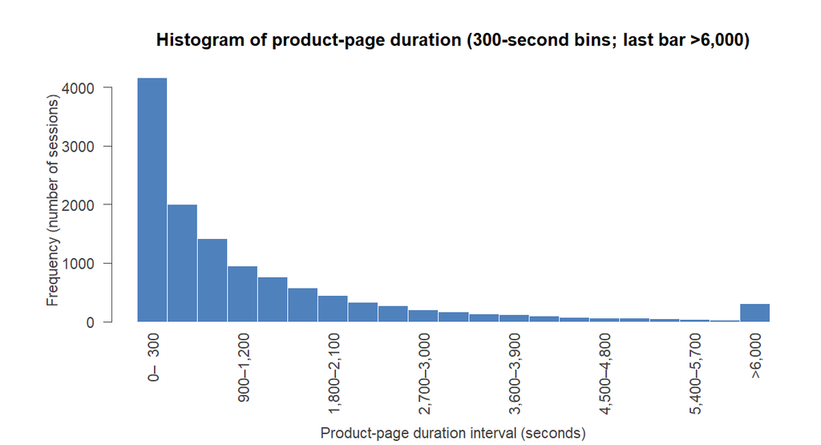

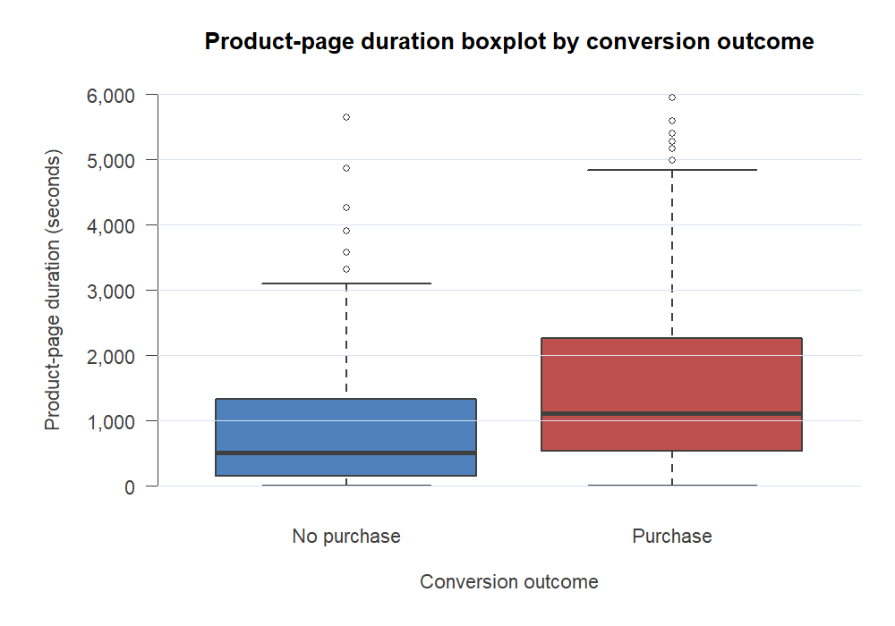

The histogram uses 300-second intervals for all 12,330 sessions. Most sessions are concentrated in the lower-duration bins, and the frequencies decline as duration increases, showing a strongly right-skewed distribution. The last bar is an overflow bin for sessions above 6,000 seconds, so no observations are removed. The boxplot compares purchase and non-purchase sessions and displays the 0–6,000 second range for readability; more extreme observations remain included in all calculations and their IQR counts are reported in the descriptive-statistics table.

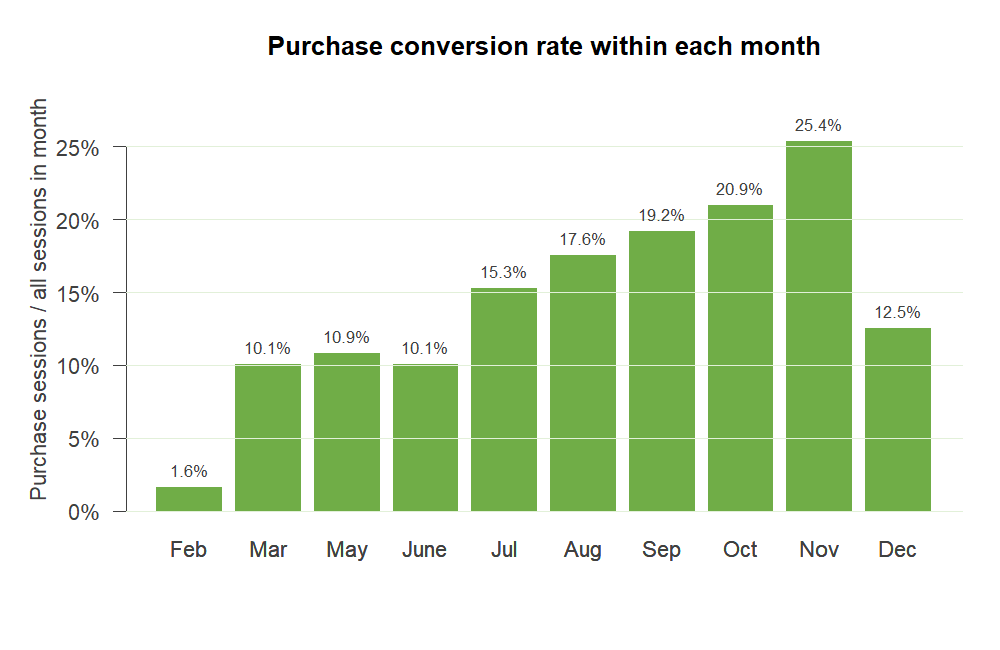

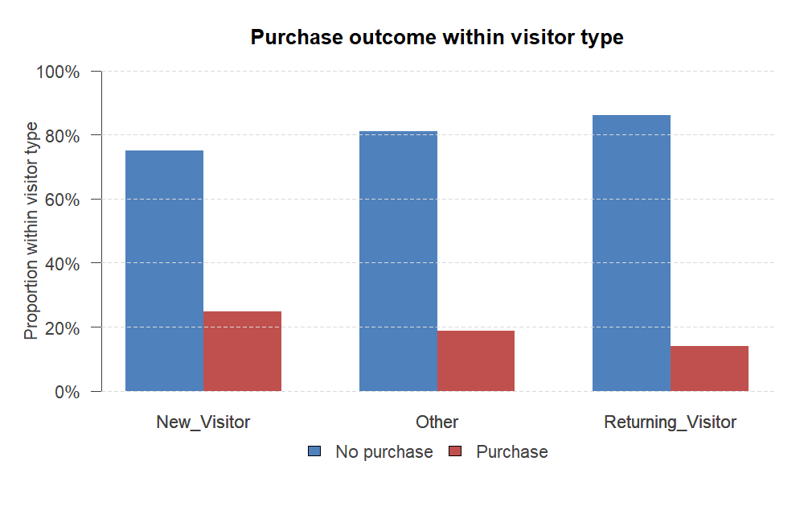

Each monthly bar is calculated independently as purchase sessions divided by all sessions observed in that month, so the bars are not components that should sum to 100%. Purchase outcome also varies across visitor types. These descriptive differences are associations and should not be interpreted as causal effects.

# 3 Task 2 - Inference for One Population

## 3.1 Population mean

We test whether mean product-page duration differs from 1,200 seconds using a two-sided one-sample t procedure at the 5% significance level.

| Measure | Value |
| --- | --- |
| n | 12330 |
| Sample mean | 1194.74621996883 |
| Sample SD | 1913.669287872 |
| Hypothesized mean | 1200 |
| t statistic | -0.304850236850555 |
| Degrees of freedom | 12329 |
| Two-sided p-value | 0.760485363690732 |
| 95% CI lower | 1160.96494182988 |
| 95% CI upper | 1228.52749810778 |
| Decision | Fail to reject H0 |

The estimated mean is approximately 1,194.7 seconds. The p-value is greater than 0.05, so there is insufficient evidence that the population mean differs from 1,200 seconds.

## 3.2 Population proportion

We test whether the conversion proportion differs from 15% using a large-sample two-sided z procedure.

| Measure | Value |
| --- | --- |
| Sessions n | 12330 |
| Purchases x | 1908 |
| Sample proportion | 0.154744525547445 |
| Hypothesized proportion | 0.15 |
| z statistic | 1.47543212553581 |
| Two-sided p-value | 0.140096403745452 |
| 95% CI lower | 0.148360888364276 |
| 95% CI upper | 0.161128162730615 |
| Decision | Fail to reject H0 |

The estimated conversion rate is approximately 15.47%. The p-value is greater than 0.05, so there is insufficient evidence that conversion differs from the selected 15% benchmark.

# 4 Task 3 - Comparison of Two Populations

## 4.1 Difference between two means

Purchase and non-purchase sessions are compared using Welch’s independent-samples t procedure because group sizes and variances differ.

| Measure | Value |
| --- | --- |
| Purchase n | 1908 |
| Purchase mean | 1876.2096148889 |
| Purchase SD | 2312.21439167297 |
| No-purchase n | 10422 |
| No-purchase mean | 1069.98780915444 |
| No-purchase SD | 1803.79775675192 |
| Difference | 806.221805734462 |
| Welch t | 14.4469889975526 |
| Welch df | 2350.27345415916 |
| Two-sided p-value | 0.00000000000000000000000000000000000000000000217379104377348 |
| 95% CI lower | 696.788630216247 |
| 95% CI upper | 915.654981252676 |
| Decision | Reject H0 |

Purchase sessions spend approximately 806 additional seconds on product-related pages. The difference is statistically significant and practically substantial.

## 4.2 Difference between two proportions

The returning-visitor proportions of purchase and non-purchase sessions are compared using a pooled z test and an unpooled confidence interval.

| Measure | Value |
| --- | --- |
| Purchase returning count | 1470 |
| Purchase n | 1908 |
| Purchase proportion | 0.770440251572327 |
| No-purchase returning count | 9081 |
| No-purchase n | 10422 |
| No-purchase proportion | 0.8713298791019 |
| Difference | -0.100889627529573 |
| Pooled proportion | 0.855717761557178 |
| z statistic | -11.5307615438008 |
| Two-sided p-value | 0.000000000000000000000000000000923234010878834 |
| 95% CI lower | -0.120824730711875 |
| 95% CI upper | -0.0809545243472704 |
| Decision | Reject H0 |

The returning-visitor shares differ significantly. This comparison concerns group composition and does not by itself prove that new visitors have a higher individual probability of purchase.

# 5 Task 4 - Simple Linear Regression

X is the number of product-related pages viewed, and Y is total product-page duration in seconds. These variables form an interpretable engagement model: viewing more product pages should generally require more total browsing time.

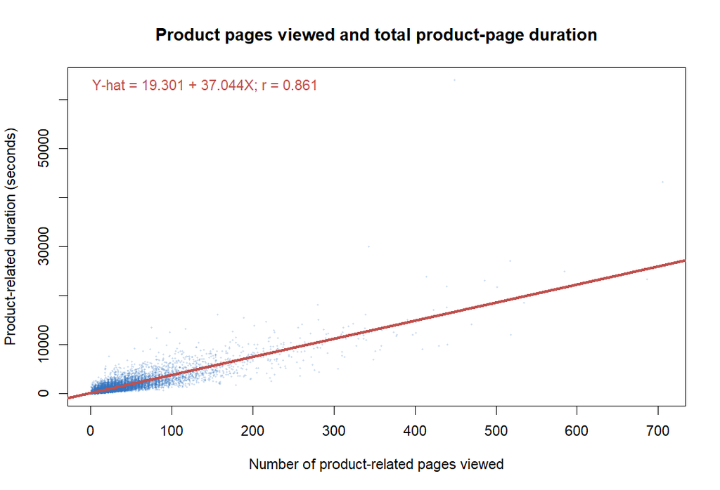

The scatter plot shows a strong positive and approximately linear relationship, with increasing spread at high page counts.

| Measure | Value |
| --- | --- |
| Observations n | 12330 |
| Correlation r | 0.86092683617637 |
| R squared | 0.741195017248654 |
| Intercept | 19.3009166234263 |
| Slope | 37.0435211086784 |
| Residual standard error | 973.578147173377 |
| Slope standard error | 0.197145114622822 |
| Slope t statistic | 187.899767029734 |
| Slope p-value | 0 |
| Slope 95% lower | 36.6570858440866 |
| Slope 95% upper | 37.4299563732703 |
| Decision | Reject H0 |

The fitted equation is approximately Y-hat = 19.30 + 37.04X. Each additional product page is associated with about 37 additional seconds of product-page time on average. The slope is statistically different from zero. The model measures engagement mechanics and should not be interpreted as a causal model of purchase completion.

## 5.1 Predictions

| ProductRelated | fit | lwr | upr |
| --- | --- | --- | --- |
| 10 | 389.74 | 370.61 | 408.86 |
| 25 | 945.39 | 928.01 | 962.77 |
| 50 | 1871.48 | 1852.90 | 1890.06 |
| 100 | 3723.65 | 3692.17 | 3755.14 |
| 200 | 7428.01 | 7360.75 | 7495.26 |

# 6 Task 5 - Final Interpretation

## 6.1 Key findings

| Analysis | Finding |
| --- | --- |
| EDA | 1908 purchase and 10422 non-purchase sessions; no missing values; right-skewed behavioral measures with high-end outliers. |
| One mean | Mean duration 1194.7 seconds; 95% CI 1161.0 to 1228.5; p = 0.7605 against 1,200 seconds. |
| One proportion | Conversion 15.47%; 95% CI 14.84% to 16.11%; p = 0.1401 against 15%. |
| Two means | Buyers spend 806.2 seconds longer on product pages; 95% CI 696.8 to 915.7; p < .001. |
| Two proportions | Returning-visitor share difference -10.1 percentage points; 95% CI -12.1 to -8.1; p < .001. |
| Regression | r = 0.861, R-squared = 74.1%, Y-hat = 19.30 + 37.04X; slope p < .001. |

The duration difference is both statistically significant and practically large: converted sessions spend roughly 13.4 additional minutes on product pages. The visitor-composition difference is statistically significant but requires cautious interpretation. The regression relationship is practically strong because product-page count explains a large proportion of engagement-time variation. In contrast, the overall mean and conversion rate are close to their selected benchmarks and are not statistically significant.

## 6.2 Conclusions and implications

| Number | Conclusion |
| --- | --- |
| 1 | Deeper product exploration is strongly associated with successful conversion. |
| 2 | High bounce and exit behavior is concentrated more strongly among non-purchase sessions. |
| 3 | Product-page count predicts engagement time but does not establish purchase causation. |
| 4 | Visitor-type conversion rates should be examined before targeting returning versus new visitors. |
| 5 | A/B tests are needed to establish causality; this observational dataset supports association and inference. |

## 6.3 Limitations

The dataset covers anonymized sessions and does not include transaction amount, demographic information, or a repeat-user identifier. Several variables are strongly skewed, and the two purchase groups are unbalanced. The analyses rely on independence and large-sample assumptions. Observational associations do not establish causality; controlled experiments such as A/B tests are required for causal platform decisions.

# 7 Data Source

UCI Machine Learning Repository, Online Shoppers Purchasing Intention Dataset:  
https://archive.ics.uci.edu/dataset/468/online+shoppers+purchasing+intention+dataset